# Final Exercise Day1: Solutions

For the final exercise, we’re going to take a closer look at items from IKEA. [Here](https://github.com/rfordatascience/tidytuesday/blob/master/data/2020/2020-11-03/readme.md) you can find a short description of the data, a codebook and the data itself.

1. If you haven’t done so already, install the readr or the tidytuesdayR package to get the data.

```r
ikea <- readr::read_csv('https://raw.githubusercontent.com/rfordatascience/tidytuesday/master/data/2020/2020-11-03/ikea.csv')
```

2. What are the dimensions of the dataset? How many columns and rows does it contain? Store this information in separate objects. (Hint: dim(), nrow(), and ncol() are your friends)

```r
dimensions <- dim(ikea)
dimensions
```

```
## [1] 3694   14
```

```r
number_rows <- nrow(ikea)
number_columns <- ncol(ikea)

paste("Rows:", number_rows, "/", "Columns:", number_columns)
```

```
## [1] "Rows: 3694 / Columns: 14"
```

3. To grasp the prices more easily, create a new column with the price conversion in Swiss Francs. One Saudi Riyal roughly corresponds to 0.25 CHF. What’s the median and mean price, respectively, in CHF?

```r
ikea$chf <- ikea$price*0.25

median(ikea$chf)
```

```
## [1] 136.175
```

```r
mean(ikea$chf)
```

```
## [1] 269.5521
```

4. Plot the price distribution and name the title and the x-axis properly.

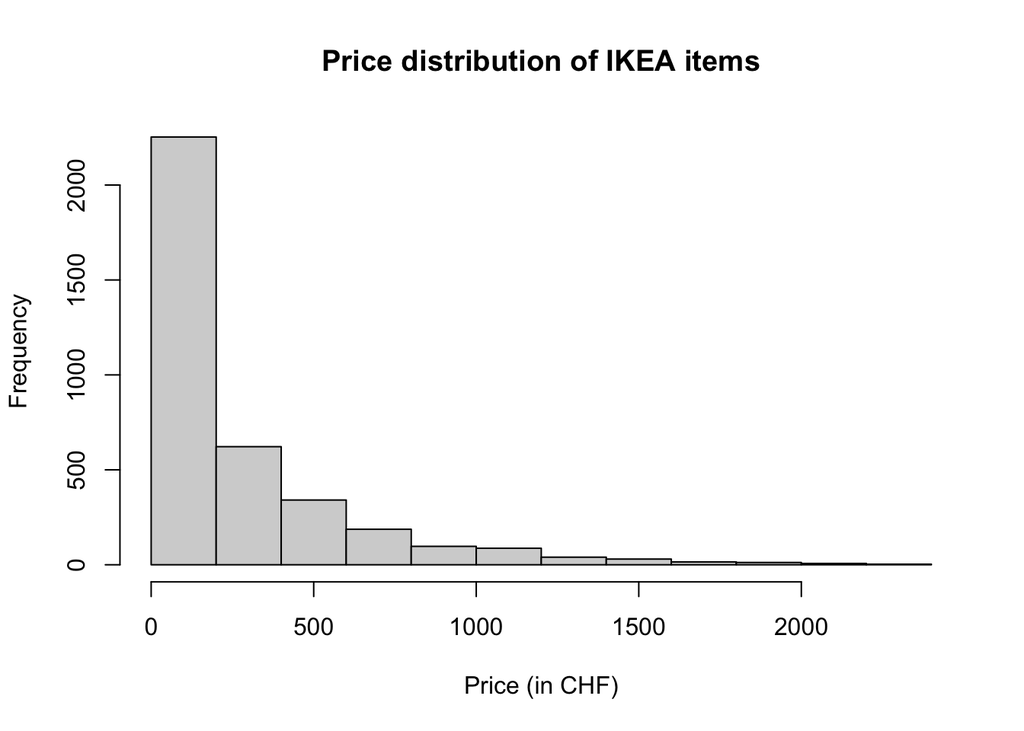

```r
hist(ikea$chf,
     main = "Price distribution of IKEA items",
     xlab = "Price (in CHF)")
```

5. Next, compute the volume of each item and store it in a new column. Is the distribution as skewed as the previous one?

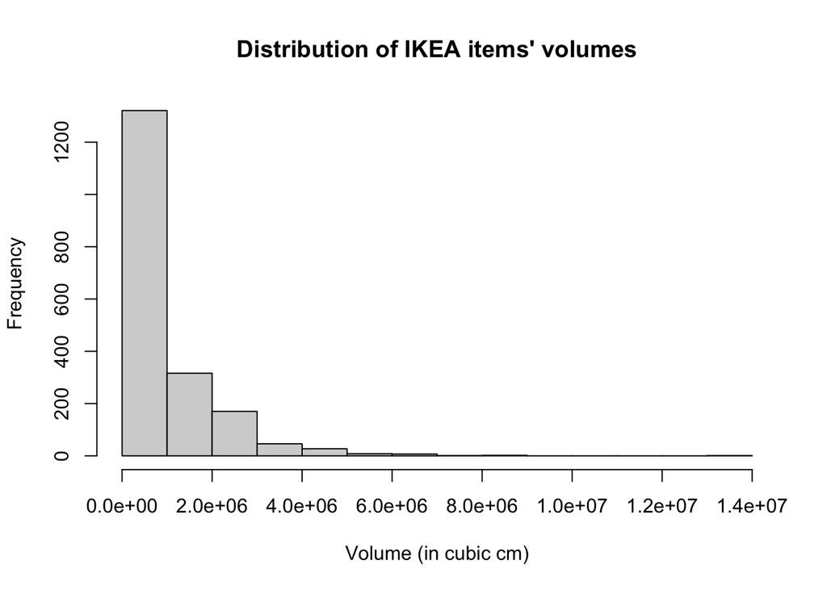

```r
ikea$volume <- ikea$depth*ikea$height*ikea$width

hist(ikea$volume,
     main = "Distribution of IKEA items' volumes",
     xlab = "Volume (in cubic cm)")
```

6. Since a lot of items cost less than 100CHF, let’s have a closer look and create a separate data frame for them. But don’t forget to save the complete dataset in your workspace!

```r
cheap_items <- ikea[ikea$chf < 100,]

save(ikea, file = "ikea.RData")
```

7. Now, let’s have a closer look at the cheaper items. How does height relate to width? Visualize the correlation and properly name the axes. And are more voluminous items also more expensive?

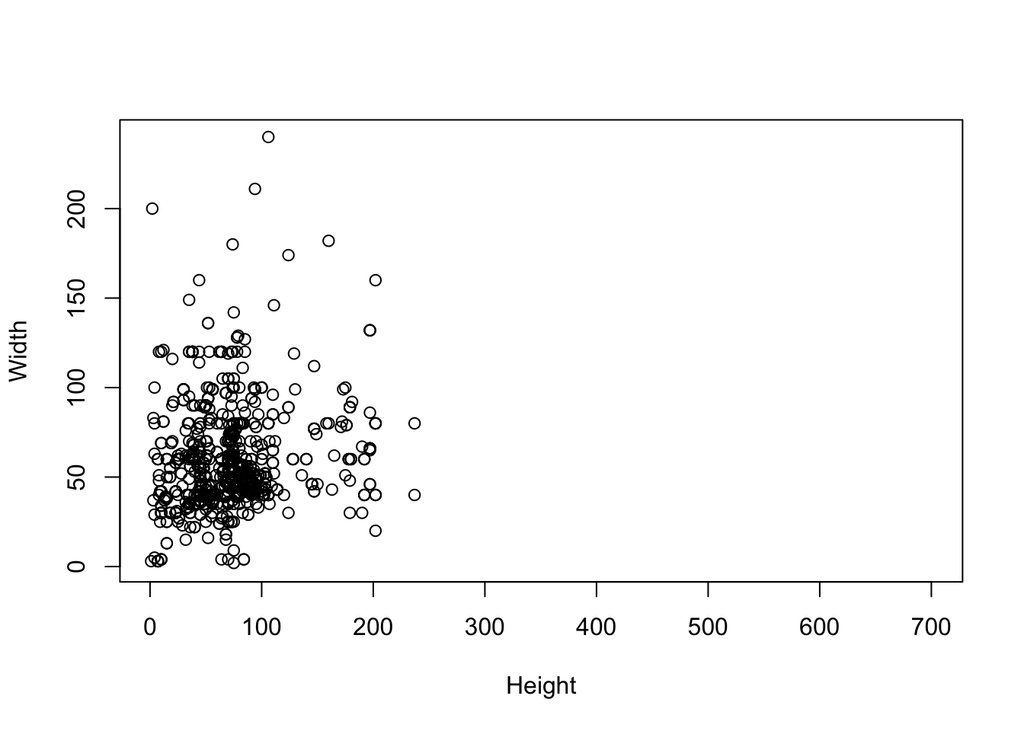

```r
plot(cheap_items$height, cheap_items$width,
     xlab = "Height",
     ylab = "Width")
```

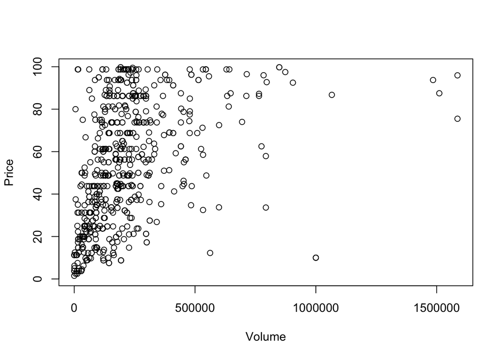

```r
plot(cheap_items$volume, cheap_items$chf,
     xlab = "Volume",
     ylab = "Price")
```

8. Now, back to the original dataset. Some items were on discount, but most of them weren’t. Indicate that in a new variable called “discount”. All items with “No old price” count as no discount, the rest as a discount. If you’re not sure how the ifelse()-function works, check out the corresponding help file.

```r
ikea$discount <- ifelse(ikea$old_price == "No old price", 0, 1)
```

9. How many items were on discount? And what’s the share of items that come in different colours?

```r
nrow(ikea[ikea$discount == 1, ])
```

```
## [1] 654
```

```r
nrow(ikea[ikea$other_colors == "Yes", ])/nrow(ikea)
```

```
## [1] 0.4093124
```

10. Great job, you completed the final exercise of Day 1! By now, you should know how to …
- create, call and store objects
- load data frames
- install and load packages
- subset data frames
- create new columns
- use the ifelse()-function
- create basic histograms and scatterplots

If you’re unsure about some of these tasks, check out the slides or the help files. You can also have a look at other useful functions such as str(), unique() or head(). Or you can help your peers and check your knowledge while explaining the tasks to them.